# Comparing Indices

#### Note for user regarding this R Notebook:

This notebook compares all indices to one another. In order to knit the document fully, we must first include all the code to build the indices (including loading and subsetting the data, re-leveling the variables, and building the MCA models), as the comparison plots reference the values generated by the MCA models. These pieces of code will make the notebook longer to knit, but will not appear in the output file.

#### Pulling/manipulating data before importing to R

In IPUMS-I: Select variables to include as many of  
(COUNTRY, YEAR, SAMPLE, SERIAL, PERNUM, PERWT, RESIDENT preselected),  
HHWT, PERSONS, OWNERSHIP, ELECTRIC, WATSUP, SEWAGE, FUELCOOK, TRASH, HEAT, AIRCON, ROOMS, TOILET, FLOOR, WALL, ROOF,  
PHONE, CELL, AUTOS, REFRIG, TV, RADIO,  
CHBORN, SCHOOL, EDATTAIN, AND OCCISCO  
as are available.

In JMP: Uncheck “Use value labels” for all variables that were not preselected.

Note: Search for USER ACTION to find places in this code that require user consideration for each country sample.

## Index Comparisons

USER ACTION: Begin reviewing code for index comparisons here.

#### Scatterplots:

##### Household wealth scores of Index 2 vs Indicies 1, 3, and 4

Index 2 vs Index 1:

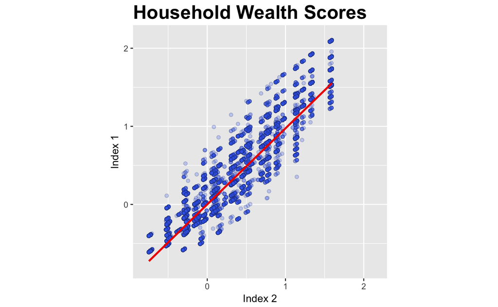

Index 2 vs Index 3:

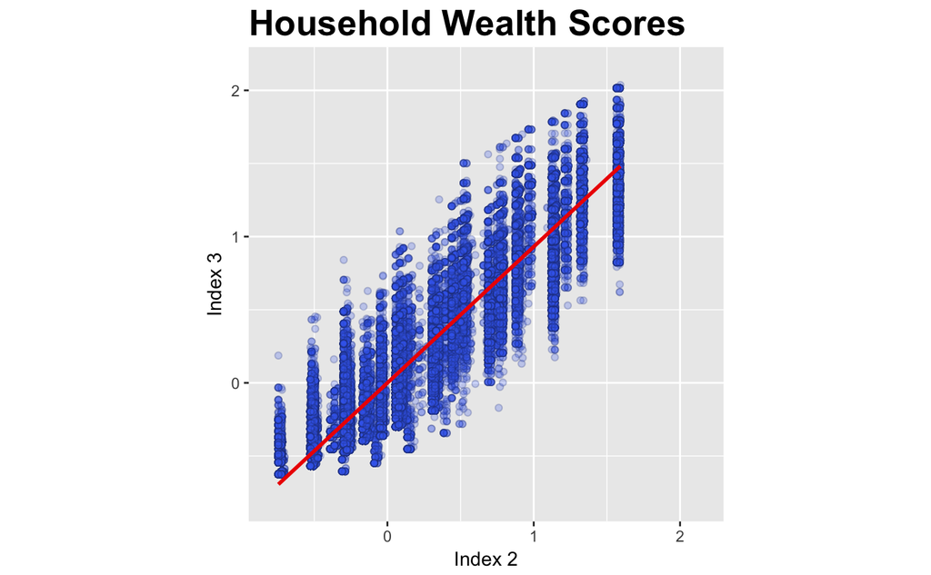

Index 2 vs Index 4:

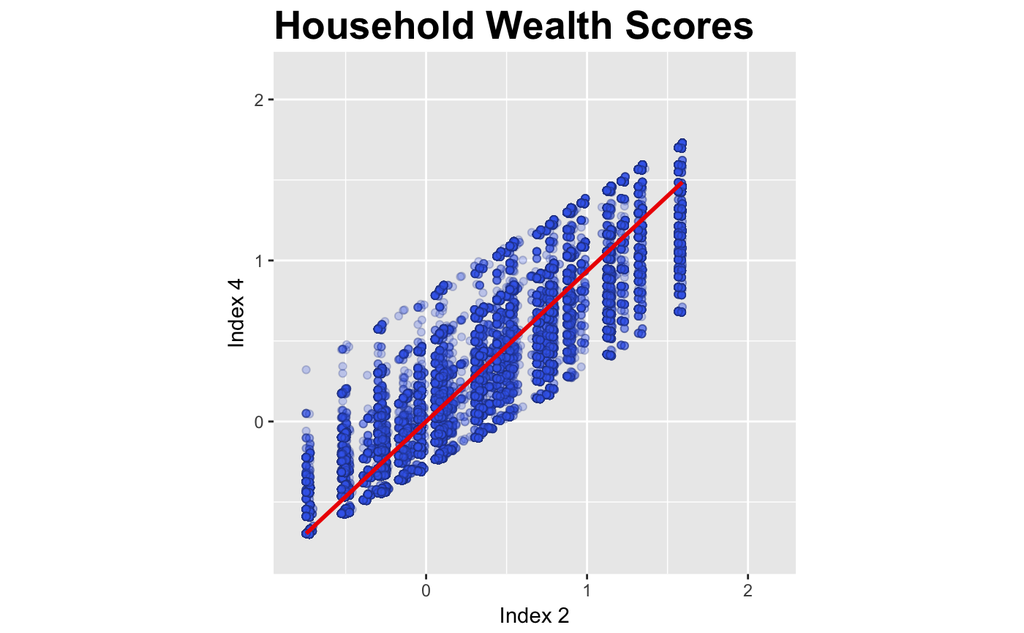

##### Household wealth scores of Index 1 vs Index 3

How does including appliance information affect the wealth index?

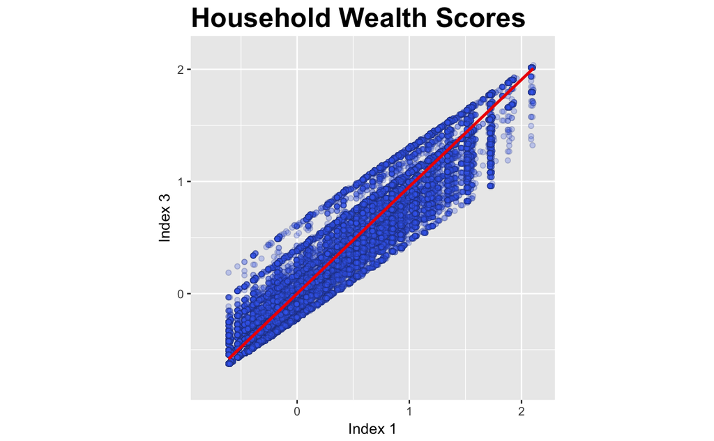